# Preparação e Análise de Texto em R com *stringr* e *tidytext*

Neste tutorial faremos uma rápida introdução aos pacotes *stringr* e *tidytext* para prepração da dados textuais para a análise. Nosso objetivo é saber transformar e identificar padrões em textos para que posssamos organizar e prepar uma coleção de documentos para análise após a coleta via raspagem de dados e/ou após a extração a partir de documentos de imagem/pdf.

Com o pacote *stringr* aprenderemos a fazer manipulações simples nos conjuntos de dados, como buscas com expressões regulares simples, remoção de caracateres, transformação em maiúsculas e minúsculas, remoção de espaços extras e etc.

A seguir, utilizaremos o pacote *tidytext*, que organiza um *corpus* como data frame e torna o trabalho de manipulação das informações relativamente simples.

O pacote *tidytext* é acompanhado de um livro em formato digital aberto que contém exemplos interessantes e úteis de como analisar textos: [Text Mininig with R](http://tidytextmining.com/).

Depois de terminar este tutorial, sugiro a leitura de um dos seguintes capítulos do livro que, após este tutorial, podem ser lidos em qualquer ordem e de maneira independente:

- [Capítulo 2 - Análise de Sentimento (com textos em inglês)](http://tidytextmining.com/sentiment.html)
- [Capítulo 3 - Análise de frequência de palavras](http://tidytextmining.com/tfidf.html)
- [Capítulo 4 - Relacionamento entre palavras, n-gramas e correlação](http://tidytextmining.com/ngrams.html)
- [Capítulo 6 - Topic Modeling](http://tidytextmining.com/topicmodeling.html)

## Prepararão para o tutorial: pacotes e objeto *corpus*

Vamos utilizar os seguintes pacotes:

- **stringr**: funções de manipulação de strings (prefixo `str_`).
- **tidyverse**: manipulação de dados em data frames (`dplyr`, `tibble`, `purrr`, etc.).
- **tidytext**: organização do **corpus** em formato “*tidy*” e funções para tokenização e análises.
- **tm**: lista de *stopwords* (português e inglês).
- **wordcloud**: construção de nuvens de palavras.

Se ainda não tiver instalado tais pacotes, instale-os:

```r
install.packages('stringr')
install.packages('tidyverse')
install.packages('tidytext')
install.packages('tm')
install.packages('wordcloud')
```

A seguir, carregue todos:

```r
library(stringr)
library(tidyverse)
```

```r
library(tidytext)
library(tm)
library(wordcloud)
```

Vamos agora carregar os textos que analisaremos. Há no curso um tutorial sobre como criar um corpus a partir da raspagem dos textos das páginas dos parques nacionais na Wikipedia. Você pode fazê-lo antes desse, se quiser aprender um pouco sobre o assunto.

*Corpus*, no contexto do análise de dados, é o conjunto de documentos textuais. Em R podemos representá-lo como lista ou como um data frame. Deve sempre conter pelo menos dois atributos mínimos: um identificador e o conteúdo do texto (texto). Pode conter também outros metadados daquele texto, como autoria, data, grupo de documentos ao qual pertence, etc.

O *corpus* que vamos utilizar neste tutorial pode ser carregado diretamente fazendo:

```r
corpus_docs <- readr::read_csv2('https://raw.githubusercontent.com/leobarone/aula-cci-webscraping-text/refs/heads/master/data/tabelas-parques-utf8.csv', locale = locale(encoding = 'UTF-8')) %>%
  rename(url_parque = url_pagina_parque, texto = texto_parque)
```

```
## ℹ Using "','" as decimal and "'.'" as grouping mark. Use `read_delim()` for more control.
```

Observe o cabeçalho da nova base: a variável **`id`** já identifica numericamente cada parque. Além dela, temos informações como **`nome`**, **`localizacao`**, **`data_de_criacao`**, **`area`** e **`descricao`**. As colunas que contêm o endereço e o texto de cada página são **`url_pagina_parque`** e **`texto_parque`**. Com a função `rename()`, passamos a chamá-las **`url_parque`** e **`texto`**, sem alterar o identificador **`id`**. As demais informações permanecem no data frame e poderão ser utilizadas em outras análises.

## Limpeza e preparação de textos com *stringr*

O pacote *stringr* é relativamente simples de utilizar. Suas funções principais começam com `str_` e o **primeiro argumento** é sempre um **vetor de texto** (ou uma coluna de texto em um data frame) a ser modificado ou a partir do qual extrairemos informação.

Os vetores de texto podem ser objetos no seu “Environment” ou variáveis dentro de um data frame. Neste tutorial, vamos preferir trabalhar com textos como variáveis em um data frame, que é uma situação usual na maioria dos projetos. Por esta razão, vamos utilizar as funções do pacote **stringr** dentro do verbo `mutate()` do pacote **dplyr**, pois estaremos modificando uma coluna ou criando uma nova variável.

### Remover acentos

Antes de seguir para as funções do **`stringr`**, vamos criar uma função bastante útil para trabalhar com textos em português: a função `remove_acentos()`, que encontrei há vários anos em algum fórum ou código cuja autoria não me lembro:

```r
remove_acentos <- function(x) iconv(x, to = "ASCII//TRANSLIT")
```

Seu uso e resultado são elementares: o texto modificado perde todos os acentos e caracteres especiais, como ç, por exemplo:

```r
corpus_docs <- corpus_docs %>%
  mutate(texto = remove_acentos(texto))
```

É conveniente remover os acentos ao trabalharmos com um corpus, em particular quando suspeitamos que uma parte dos textos já esteja sem acentuação e a outra não.

### Padronizar minúsculas/maiúsculas

Como em R há diferenciação entre letras maiúsculas e minúsculas, convém também tornar o texto completo em minúsculo. Podemos utilizar a função `str_to_lower` do pacote `stringr`. Ela é semelhante à função `tolower` do pacote `base` de R. Como o R diferencia maiúsculas e minúsculas, convém tornar o texto todo **minúsculo**:

```r
corpus_docs <- corpus_docs %>%
  mutate(texto = str_to_lower(texto))
```

`str_to_upper`, por sua vez, transformaria todos os caracteres em maísculo e `str_to_title` manteria em maísculo apenas o primeiro caracter de cada palavra e os demais em minúsculo.

### Remover pontuação

Outra limpeza comum na preparação de textos é a remoção de todo a pontuação. A função `str_remove_all` nos permite remover uma padrão de dentro de um texto. Por exemplo, para removermos todas as palavras “artigo” faríamos `str_remove_all(texto, "artigo")`. Para remover pontuação, porém, precisamos de uma expressão regular que represente “qualquer caracter de pontuação”, como a expressão `[:punct:]`.

```r
corpus_docs <- corpus_docs %>%
  mutate(texto = str_remove_all(texto, '[:punct:]'))
```

Expressões regulares são grandes aliadas das funções do pacote `stringr`. Ao final do tutorial há uma indicação onde você pode aprender um pouco mais como escrever expressões regulares.

Vejamos como ficaram os primeiros mil caracateres do texto depois de modificado:

```r
corpus_docs %>%
  slice(2) %>%             # seleciona o 1o texto
  pull(texto) %>%          # retira do data frame como vetor
  str_sub(1, 1000)         # limita do 1o ao milesimo caracter
```

```
## [1] "o parque nacional do alto cariri e um parque nacional brasileiro localizado na bahia e criado em 11 de junho de 2010 possui cerca de 19264 hectares protegendo remanescentes de mata atlantica da bahia juntamente com a parque estadual alto cariri e refugio de vida silvestre mata dos muriquis a…
```

### Normalização de espaços

Há muitos espeços inúteis no texto provenientes da formatação das páginas da Wikipedia. Com `str_squish` podemos remover estes espaços que estão sobrando e comprimir múltiplos espaços internos em um único:

```r
corpus_docs <- corpus_docs %>%
  mutate(texto = str_squish(texto))
```

### Substituição de textos

Por vezes, há palavras inteiras que queremos substituir no texto (ou padrões de carateres). `str_replace` e `str_replace_all` cumprem essa função. `str_replace` substitui o **primeiro** substitui **apenas a primeira ocorrência** de um padrão por outro.

```r
# Ex.: trocar a primeira ocorrencia de "parque nacional" por "PN"
corpus_docs <- corpus_docs %>%
  mutate(texto = str_replace(texto, "parque nacional", "PN"))
```

Para substituir **todas** as ocorrências, usamos `str_replace_all()`.

```r
# Ex.: trocar todas as ocorrencias de "parque nacional" por "PN"
corpus_docs <- corpus_docs %>%
  mutate(texto = str_replace_all(texto, "parque nacional", "PN"))
```

### Remoção de textos

```r
# Ex.: remove todas as ocorrencias da palavra brasileiro
corpus_docs <- corpus_docs %>%
  mutate(texto = str_remove_all(texto, "brasileiro"))
```

### Medidas simples e detecção de padrões

**Qual dos textos do nosso *corpus* é o mais longo?** Vamos criar uma variável de **tamanho** (em caracteres) dos textos:

```r
corpus_docs <- corpus_docs %>%
  mutate(tamanho = str_length(texto))
```

**Vamos agora identificar padrões** dentro de nossos textos. Há 3 funções muito úteis e similares para identificar padrões. Antes de utilizá-las dentro do data frame completo, vamos aplicá-las a um **vetor de textos** para entender seus resultados. Compare com os termos **“mata atlantica”** e **“serra”**:

```r
# Vetor lógico com TRUE/FALSE por linha
str_detect(corpus_docs$texto, "mata atlantica")
```

```
##  [1] FALSE  TRUE FALSE FALSE  TRUE FALSE FALSE  TRUE FALSE FALSE FALSE FALSE
## [13] FALSE FALSE  TRUE  TRUE FALSE FALSE  TRUE FALSE FALSE  TRUE FALSE FALSE
## [25] FALSE  TRUE  TRUE FALSE  TRUE FALSE FALSE FALSE FALSE FALSE FALSE FALSE
## [37] FALSE FALSE FALSE FALSE FALSE FALSE FALSE FALSE FALSE FALSE  TRUE FALSE
## [49] FALSE FALSE FALSE  TRUE  TRUE FALSE  TRUE FALSE  TRUE FALSE  TRUE FALSE
## [61] FALSE  TRUE FALSE  TRUE FALSE  TRUE  TRUE FALSE FALSE  TRUE  TRUE FALSE
## [73] FALSE  TRUE  TRUE FALSE
```

```r
str_detect(corpus_docs$texto, "serra")
```

```
##  [1] FALSE FALSE FALSE FALSE  TRUE FALSE  TRUE FALSE FALSE FALSE  TRUE FALSE
## [13]  TRUE FALSE  TRUE  TRUE FALSE FALSE  TRUE  TRUE  TRUE FALSE  TRUE FALSE
## [25] FALSE  TRUE  TRUE FALSE  TRUE FALSE FALSE FALSE FALSE FALSE FALSE FALSE
## [37] FALSE FALSE FALSE  TRUE FALSE  TRUE FALSE  TRUE  TRUE  TRUE FALSE  TRUE
## [49] FALSE FALSE FALSE  TRUE  TRUE  TRUE  TRUE  TRUE  TRUE  TRUE  TRUE  TRUE
## [61]  TRUE  TRUE  TRUE  TRUE  TRUE  TRUE  TRUE  TRUE  TRUE  TRUE  TRUE  TRUE
## [73] FALSE  TRUE  TRUE FALSE
```

`str_detect` procura, em cada um dos textos do vetor, o padrão informado no segundo parâmetro e retorna um vetor lógico indicando quais textos contêm o padrão.

```r
# Índices (posições) onde aparece
str_which(corpus_docs$texto, "mata atlantica")
```

```
##  [1]  2  5  8 15 16 19 22 26 27 29 47 52 53 55 57 59 62 64 66 67 70 71 74 75
```

```r
str_which(corpus_docs$texto, "serra")
```

```
##  [1]  5  7 11 13 15 16 19 20 21 23 26 27 29 40 42 44 45 46 48 52 53 54 55 56 57
## [26] 58 59 60 61 62 63 64 65 66 67 68 69 70 71 72 74 75
```

`str_which`, por sua vez, também procura os padrões informados, mas retorna um **vetor com as posições** dos textos que contêm o padrão.

```r
# Subconjuntos com os textos que contêm o padrão
str_subset(corpus_docs$texto, "mata atlantica") %>% str_sub(1,300)
```

```
##  [1] "o PN do alto cariri e um PN  localizado na bahia e criado em 11 de junho de 2010 possui cerca de 19264 hectares protegendo remanescentes de mata atlantica da bahia juntamente com a parque estadual alto cariri e refugio de vida silvestre mata dos muriquis ambos em minas gerais forma um dos m…
##  [2] "o PN de aparados da serra e uma unidade de conservacao brasileira de protecao integral da natureza localizada na serra geral encampando os desfiladeiros na divisa natural entre os estados do rio grande do sul e de santa catarina12a unidade foi criada atraves do decreto no 47446 de 17 de dez…
##  [3] "o PN de boa nova e um PN  situado no estado da bahia ele tem uma area total superior a doze mil hectares que cobre os municipios de boa nova dario meira e manoel vitorinocriado por decreto em 11 de junho de 2010 o sitio se localiza no bioma da mata atlantica e apresenta quatro tipos de vege…
##  [4] "o PN de caparao foi criado em 24 de maio de 1961 pelo decreto federal no 506462 assinado entao pelo presidente janio quadros abriga o terceiro pico mais alto do pais o pico da bandeira e administrado pelo instituto chico mendes de conservacao da biodiversidade icmbio o parque possui 31800 h…
##  [5] "o PN do catimbau tambem conhecido como vale do catimbau e um PN  do estado de pernambuco criado em 13 de dezembro de 20021 o parque abrange uma area de 6229414 hectares e esta localizado na regiao central de pernambuco entre o agreste e o sertao pernambucano nos municipios de buique tupanat…
##  [6] "PN da chapada diamantina abreviado como parnacd no registro oficial e um PN  criado em 17 de setembro de 1985 atraves do decreto federal 916551 com uma area de 152 mil hectares na regiao central da chapada diamantina distribuido pelos municipios de lencois mucuge ibicoara andarai e palmeira…
##  [7] "o PN do descobrimento e um dos parques nacionais s e compoe junto com o PN do monte pascoal e o do pau brasil um corredor ecologico das reservas de mata atlantica da costa do descobrimento foi criado em 20 de abril de 1999 proximo das comemoracoes dos 500 anos do brasil como tentativa de pr…
##  [8] "o PN guaricana e um PN  localizado no parana criado para proteger remanescentes de mata atlantica na serra do mar paranaense1 mesmo nao sendo totalmente implementado ja apresenta intensa visitacao2este PN desempenha um papel importante na preservacao de especies endemicas e ameacadas da fau…
##  [9] "PN do iguacu e uma area protegida brasileira do grupo das unidades de conservacao esta localizado na regiao extremo oeste paranaense a 17 km do centro da cidade de foz do iguacu e a apenas 5 km do aeroporto internacional de foz do iguacu o PN tem uma area total de 169 69588 hectares e nele …
## [10] "o PN do itatiaia5 e uma unidade de conservacao brasileira de protecao integral da natureza localizada no macico do itatiaia na serra da mantiqueira entre os estados do rio de janeiro e minas gerais itatiaia e o PN mais antigo do brasil6 tendo sido criado em 14 de junho de 1937 numa area de …
## [11] "o PN do paubrasil e uma das mais importantes unidades de conservacao integral do estado da bahia esta situado integralmente no municipio de porto seguro e integra o bioma da mata atlantica sua area fica por volta dos dezenove mil hectares e o terreno consiste de uma planicie costeira relati…
## [12] "o PN de sainthilairelange saent hilare esta localizado no litoral do estado do parana e abrange os municipios de matinhos guaratuba morretes e paranagua ocupa um trecho da serra do mar conhecido como serra da prata e possui area de 25 11914 ha12foi criado em 23 de maio de 2001 pela lei fede…
## [13] "o PN de sao joaquim e uma unidade de conservacao brasileira de protecao integral da natureza localizado nas regioes serrana e sul do estado de santa catarina com territorio distribuido pelos municipios de bom jardim da serra graopara lauro muller orleans e urubici13criado em 6 de julho de 1…
## [14] "o PN da serra da bocaina localizase na divisa entre os estados do rio de janeiro e de sao paulo na regiao sudeste do brasil e um segmento da serra do maro PN da serra da bocaina foi criado por decreto federal em 1971 compreende uma area aproximada de 134 mil hectares e uma expressiva biodiv…
## [15] "o PN da serra da canastra e uma unidade de conservacao federal de protecao integral localizada no sudoeste do estado de minas gerais no brasil administrado pelo instituto chico mendes de conservacao da biodiversidade icmbio o parque foi criado pelo decreto no 70355 de 3 de abril de 1972 com…
## [16] "o PN da serra do cipo e uma unidade de conservacao federal localizada no estado de minas gerais na regiao da serra do espinhaco criado em 25 de setembro de 1984 o parque possui area aproximada de 31 mil hectares e e administrado pelo instituto chico mendes de conservacao da biodiversidade i…
```

[output cut: 8 more lines]

```r
str_subset(corpus_docs$texto, "serra")%>% str_sub(1,300)
```

```
##  [1] "o PN de aparados da serra e uma unidade de conservacao brasileira de protecao integral da natureza localizada na serra geral encampando os desfiladeiros na divisa natural entre os estados do rio grande do sul e de santa catarina12a unidade foi criada atraves do decreto no 47446 de 17 de dez…
##  [2] "o PN das araucarias e uma unidade de conservacao brasileira de protecao integral a natureza situada nos municipios catarinenses de passos maia e ponte serrada1234 seu principal objetivo e o de preservar os remanescentes de floresta ombrofila mista da regiao a fim de criar um condicoes para …
##  [3] "o PN do cabo orange pnco e uma unidade de conservacao brasileira de protecao integral da natureza localizada na regiao norte do estado do amapa com territorio distribuido pelos municipios de oiapoque e calcoeneo parque forma junto aos parques nacionais montanhas do tumucumaque do monte rora…
##  [4] "o PN dos campos ferruginosos e uma unidade conservacao de protecao integral criada pelo decreto presidencial de 5 de junho de 2017 esta localizado entre as cidades paraenses de canaa dos carajas e parauapebas no sudeste do estado1o parque e formado em sua maior parte por porcoes de terras d…
##  [5] "o PN de caparao foi criado em 24 de maio de 1961 pelo decreto federal no 506462 assinado entao pelo presidente janio quadros abriga o terceiro pico mais alto do pais o pico da bandeira e administrado pelo instituto chico mendes de conservacao da biodiversidade icmbio o parque possui 31800 h…
##  [6] "o PN do catimbau tambem conhecido como vale do catimbau e um PN  do estado de pernambuco criado em 13 de dezembro de 20021 o parque abrange uma area de 6229414 hectares e esta localizado na regiao central de pernambuco entre o agreste e o sertao pernambucano nos municipios de buique tupanat…
##  [7] "PN da chapada diamantina abreviado como parnacd no registro oficial e um PN  criado em 17 de setembro de 1985 atraves do decreto federal 916551 com uma area de 152 mil hectares na regiao central da chapada diamantina distribuido pelos municipios de lencois mucuge ibicoara andarai e palmeira…
##  [8] "PN da chapada dos guimaraes e uma unidade de conservacao brasileira situada no estado de mato grosso nos municipios de chapada dos guimaraes e cuiaba que recebeu a guarida federal atraves do decreto 97656 de 12 de abril de 1989 possui uma area total de 33 mil hectares e administrado pelo in…
##  [9] "PN da chapada dos veadeiros pncv pertence ao grupo de unidades de conservacao de protecao integral conforme definido pelo sistema nacional de unidades de conservacao da natureza snuc esta localizada no bioma cerrado na regiao nordeste do estado de goias abrangendo os municipios de alto para…
## [10] "o PN das emas e uma unidade de conservacao brasileira de protecao integral a natureza2 localizada na regiao sudoeste do estado de goias o parque abrange uma area de 132 000 ha distribuidos pelos municipios de mineiros chapadao do ceu e parte de costa rica mato grosso do sulcriado atraves do…
## [11] "o PN guaricana e um PN  localizado no parana criado para proteger remanescentes de mata atlantica na serra do mar paranaense1 mesmo nao sendo totalmente implementado ja apresenta intensa visitacao2este PN desempenha um papel importante na preservacao de especies endemicas e ameacadas da fau…
## [12] "PN do iguacu e uma area protegida brasileira do grupo das unidades de conservacao esta localizado na regiao extremo oeste paranaense a 17 km do centro da cidade de foz do iguacu e a apenas 5 km do aeroporto internacional de foz do iguacu o PN tem uma area total de 169 69588 hectares e nele …
## [13] "o PN do itatiaia5 e uma unidade de conservacao brasileira de protecao integral da natureza localizada no macico do itatiaia na serra da mantiqueira entre os estados do rio de janeiro e minas gerais itatiaia e o PN mais antigo do brasil6 tendo sido criado em 14 de junho de 1937 numa area de …
## [14] "o PN montanhas do tumucumaque pnmt e uma unidade de conservacao uc brasileira de protecao integral da natureza do tipo PN localizada nos estados do amapa e do para com territorio distribuido pelos municipios de almeirim calcoene laranjal do jari oiapoque pedra branca do amapari e serra do n…
## [15] "PN do monte roraima foi criado em 28 de junho de 1989 pelo entao presidente da republica do brasil jose sarney atraves do decreto no 97887 no parque encontramse savanas florestas de altitude e rios de correnteza forte tambem se localizam no parque algumas das mais antigas montanhas da terra…
```

[output cut: 27 more lines]

Finalmente, `str_subset` seleciona, do vetor de textos, **apenas os que contêm** o padrão e retorna esse subconjunto.

**`str_detect` é bastante útil para selecionar linhas** em um data frame. Por exemplo, vamos criar um novo data frame que contenha apenas os documentos com pelo menos uma menção a “mata atlantica”:

```r
docs_mata_atlantica <- corpus_docs %>%
  filter(str_detect(texto, "mata atlantica"))
```

Ótimo! Mas vamos continuar trabalhando no **data frame completo**.

**Marcar no data frame (em vez de filtrar)**: vamos criar colunas lógicas e colunas de **contagem** de ocorrências para os dois termos:

```r
corpus_docs <- corpus_docs %>%
  mutate(
    tem_mata   = str_detect(texto, "mata atlantica"),
    tem_serra   = str_detect(texto, "serra"),
    n_mata     = str_count(texto, "mata atlantica"),
    n_serra     = str_count(texto, "serra")
  )
```

## Tidy text com *tidytext*: tokens, stopwords e frequências

Agora vamos organizar o texto em **formato *tidy***: cada linha corresponde a um **token** (palavra, bigram, trigram…). Começaremos por **palavras**.

> A ideia central: transformar a coluna `texto` em muitos registros, um por token, preservando a ligação com `id`.

### 1) Tokenização em palavras

Neste exercício, vamos trabalhar apenas com as variáveis **`id`**, **`url_parque`** e **`texto`** do nosso corpus:

```r
corpus_docs <- corpus_docs %>%
  select(id, url_parque, texto)
```

O primeiro passo para organizar um texto para análise com o pacote *tidytext* é a **tokenização** da variável de conteúdo. “Tokenizar” significa fragmentar o texto em unidades, que podem ser **palavras**, **palavras**, **duplas**, **trios** ou conjuntos ainda maiores de palavras, como **sentenças**, ou menores, como conjuntos de **caracteres**. Vamos trabalhar inicialmente com **palavras** como tokens:

```r
docs_token <- corpus_docs %>%
  unnest_tokens(word, texto)

glimpse(docs_token)
```

```
## Rows: 48,570
## Columns: 3
## $ id         <dbl> 1, 1, 1, 1, 1, 1, 1, 1, 1, 1, 1, 1, 1, 1, 1, 1, 1, 1, 1, 2,…
## $ url_parque <chr> "https://pt.wikipedia.org/wiki/Parque_Nacional_do_Acari?act…
## $ word       <chr> "o", "editor", "sera", "agora", "carregado", "se", "continu…
```

Note que as variáveis **`id`** e **`url_parque`** são mantidas. `texto`, porém, se torna `word`, organizada ordenadamente na sequência prévia dos textos. Veja que o formato de um *tidytext* é completamente diferente do data frame original, pois o conteúdo textual agora são os **tokens** (palavras).

## Palavras muito comuns: stopwords

Quando analisamos textos podemos observar, entre outros aspectos, a **frequência** ou a **co-ocorrência** entre tokens. Entretanto, em todas as línguas há palavras muito frequentes e pouco informativas sobre o conteúdo. São as **stopwords**.

O pacote `tm` contém uma lista de stopwords em português. Veja:

```r
stopwords("pt")
```

```
##   [1] "de"           "a"            "o"            "que"          "e"
##   [6] "do"           "da"           "em"           "um"           "para"
##  [11] "com"          "não"          "uma"          "os"           "no"
##  [16] "se"           "na"           "por"          "mais"         "as"
##  [21] "dos"          "como"         "mas"          "ao"           "ele"
##  [26] "das"          "à"            "seu"          "sua"          "ou"
##  [31] "quando"       "muito"        "nos"          "já"           "eu"
##  [36] "também"       "só"           "pelo"         "pela"         "até"
##  [41] "isso"         "ela"          "entre"        "depois"       "sem"
##  [46] "mesmo"        "aos"          "seus"         "quem"         "nas"
##  [51] "me"           "esse"         "eles"         "você"         "essa"
##  [56] "num"          "nem"          "suas"         "meu"          "às"
##  [61] "minha"        "numa"         "pelos"        "elas"         "qual"
##  [66] "nós"          "lhe"          "deles"        "essas"        "esses"
##  [71] "pelas"        "este"         "dele"         "tu"           "te"
```

[output cut: 26 more lines]

Dependendo do propósito da análise, podemos **ampliar manualmente** a lista de stopwords acrescentando novos termos ao vetor.

Para excluir stopwords nessa abordagem, precisamos de um **data frame** com stopwords:

```r
stopwords_df <- tibble(word = c(stopwords("pt")))
```

Com `anti_join` (função de junção do `dplyr`), mantemos em `docs_token` apenas as palavras que **não** estão em `stopwords_df`:

```r
docs_token <- docs_token %>%
  anti_join(stopwords_df, by = "word")
```

Para observarmos a **frequência de palavras**, usamos `count`, do pacote `dplyr`:

```r
docs_token %>%
  count(word, sort = TRUE) %>% View
```

Opa! Há muitos tokens que são apenas **caracteres soltos**. Em páginas da Wikipedia é comum encontrar símbolos, siglas muito curtas ou marcas de formatação. Vamos, assim, **excluir todas as palavras de 1 caracter** e rever a frequência dos tokens:

```r
docs_token <- docs_token %>%
  filter(str_length(word) > 1)

docs_token %>%
  count(word, sort = TRUE) %>% View
```

Bem melhor. Ainda seria possível aprimorar a limpeza do texto, mas podemos avançar.

Com `ggplot2`, que é um pacote gráfico de R, podemos construir um **gráfico de barras** dos termos mais frequentes (por exemplo, com frequência maior do que 50 — ajuste conforme o volume do seu corpus). Neste ponto do curso, nada do que estamos fazendo abaixo deve ser novo a você:

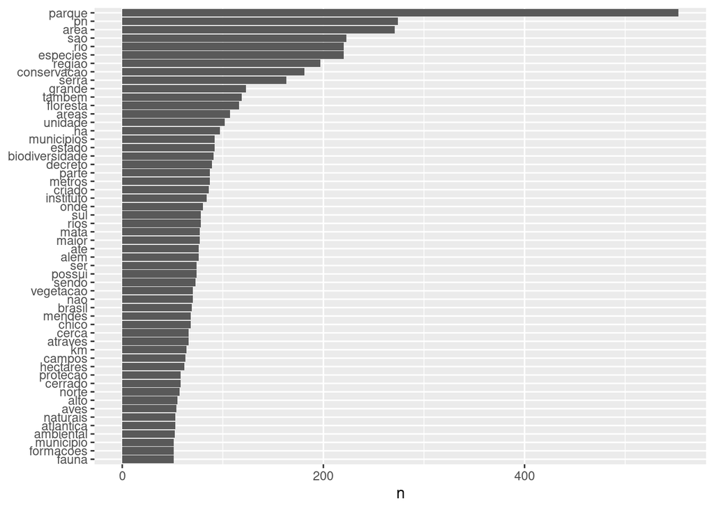

```r
docs_token %>%
  count(word, sort = TRUE) %>%
  filter(n > 50) %>%
  mutate(word = reorder(word, n)) %>%
  ggplot(aes(word, n)) +
    geom_col() +
    xlab(NULL) +
    coord_flip()
```

## Bigrams e n-grams

Já produzimos a tokenização do texto, sem, no entanto, refletir sobre esse procedimento. **Tokens não precisam ser palavras únicas**. Se o objetivo for, por exemplo, observar a **ocorrência conjunta** de termos, convém trabalharmos com **bigrams** (tokens de 2 palavras) ou **n-grams** (tokens de *n* palavras). Vejamos como:

```r
docs_bigram <- corpus_docs %>%
  unnest_tokens(bigram, texto, token = "ngrams", n = 2)
```

> Obs.: ao tokenizar o texto com `unnest_tokens`, as **pontuações** são removidas automaticamente e as palavras são convertidas para **minúsculas** (use `to_lower = FALSE` caso não queira a conversão). Em muitos fluxos, as transformações anteriores ficariam redundantes.

Vamos **contar os bigrams**:

```r
docs_bigram %>%
  count(bigram, sort = TRUE)
```

```
## # A tibble: 28,580 × 2
##    bigram             n
##    <chr>          <int>
##  1 do parque        222
##  2 o parque         159
##  3 de conservacao   150
##  4 e o              146
##  5 do rio           142
##  6 e a              134
##  7 o pn             114
##  8 da serra         100
##  9 area de           89
## 10 especies de       89
## # ℹ 28,570 more rows
```

Como excluir as **stopwords** quando elas ocorrem em bigrams? Primeiro precisamos **separar** os bigrams em duas colunas:

```r
bigrams_separados <- docs_bigram %>%
  separate(bigram, c("word1", "word2"), sep = " ")
```

Em seguida, **filtramos** excluindo stopwords em **cada posição** (reaproveitando `stopwords_df`):

```r
bigrams_filtrados <- bigrams_separados %>%
  anti_join(stopwords_df, by = c("word1" = "word")) %>%
  anti_join(stopwords_df, by = c("word2" = "word"))
```

Produzindo a **frequência de bigrams**:

```r
bigrams_filtrados %>%
  count(word1, word2, sort = TRUE)
```

```
## # A tibble: 11,489 × 3
##    word1          word2          n
##    <chr>          <chr>      <int>
##  1 chico          mendes        68
##  2 instituto      chico         67
##  3 mata           atlantica     46
##  4 protecao       integral      32
##  5 conservacao    brasileira    26
##  6 pode           ser           25
##  7 floresta       ombrofila     22
##  8 media          anual         21
##  9 biodiversidade icmbio        20
## 10 sao            francisco     20
## # ℹ 11,479 more rows
```

Reunindo as palavras do bigram (após filtragem) em uma única coluna novamente:

```r
bigrams_filtrados %>%
  unite(bigram, word1, word2, sep = " ")
```

```
## # A tibble: 14,446 × 3
##       id url_parque                                                       bigram
##    <dbl> <chr>                                                            <chr>
##  1     1 https://pt.wikipedia.org/wiki/Parque_Nacional_do_Acari?action=e… edito…
##  2     1 https://pt.wikipedia.org/wiki/Parque_Nacional_do_Acari?action=e… sera …
##  3     1 https://pt.wikipedia.org/wiki/Parque_Nacional_do_Acari?action=e… agora…
##  4     1 https://pt.wikipedia.org/wiki/Parque_Nacional_do_Acari?action=e… mensa…
##  5     1 https://pt.wikipedia.org/wiki/Parque_Nacional_do_Acari?action=e… apos …
##  6     1 https://pt.wikipedia.org/wiki/Parque_Nacional_do_Acari?action=e… algun…
##  7     1 https://pt.wikipedia.org/wiki/Parque_Nacional_do_Acari?action=e… segun…
##  8     2 https://pt.wikipedia.org/wiki/Parque_Nacional_do_Alto_Cariri     alto …
##  9     2 https://pt.wikipedia.org/wiki/Parque_Nacional_do_Alto_Cariri     pn lo…
## 10     2 https://pt.wikipedia.org/wiki/Parque_Nacional_do_Alto_Cariri     2010 …
## # ℹ 14,436 more rows
```

A abordagem *tidy* traz uma tremenda flexibilidade. Se, por exemplo, quisermos ver com quais palavras a palavra **“atlantica”** é **antecedida**:

```r
bigrams_filtrados %>%
  filter(word2 == "atlantica") %>%
  count(word1, sort = TRUE)
```

```
## # A tibble: 3 × 2
##   word1        n
##   <chr>    <int>
## 1 mata        46
## 2 floresta     6
## 3 encosta      1
```

Ou com quais palavras **“mata”** é **sucedida**:

```r
bigrams_filtrados %>%
  filter(word1 == "mata") %>%
  count(word2, sort = TRUE)
```

```
## # A tibble: 17 × 2
##    word2               n
##    <chr>           <int>
##  1 atlantica          46
##  2 ciliar              4
##  3 nativa              2
##  4 seca                2
##  5 umida               2
##  6 atlantica2          1
##  7 atlantica2a         1
##  8 atlanticao          1
##  9 atlanticaquanto     1
## 10 densa               1
## 11 pluvial             1
## 12 rala                1
## 13 regenerada          1
## 14 secundaria          1
## 15 serrana             1
## 16 situadas            1
## 17 tropical            1
```

Ou **ambos**:

```r
bind_rows(
  bigrams_filtrados %>%
    filter(word2 == "mata") %>%
    count(word1, sort = TRUE) %>%
    rename(word = word1),

  bigrams_filtrados %>%
    filter(word1 == "mata") %>%
    count(word2, sort = TRUE) %>%
    rename(word = word2)
) %>%
  arrange(desc(n))
```

```
## # A tibble: 30 × 2
##    word          n
##    <chr>     <int>
##  1 atlantica    46
##  2 ciliar        4
##  3 bioma         3
##  4 nativa        2
##  5 seca          2
##  6 umida         2
##  7 aberta        1
##  8 biomas        1
##  9 deste         1
## 10 galeria       1
## # ℹ 20 more rows
```

### Ngrams

Repetindo o procedimento para **trigrams**:

```r
corpus_docs %>%
  unnest_tokens(trigram, texto, token = "ngrams", n = 3) %>%
  separate(trigram, c("word1", "word2", "word3"), sep = " ") %>%
  anti_join(stopwords_df, by = c("word1" = "word")) %>%
  anti_join(stopwords_df, by = c("word2" = "word")) %>%
  anti_join(stopwords_df, by = c("word3" = "word")) %>%
  count(word1, word2, word3, sort = TRUE)
```

```
## # A tibble: 6,370 × 4
##    word1        word2      word3         n
##    <chr>        <chr>      <chr>     <int>
##  1 instituto    chico      mendes       67
##  2 grande       relevancia ecologica    14
##  3 oncapintada  panthera   onca         14
##  4 floresta     ombrofila  densa        12
##  5 precipitacao media      anual        11
##  6 oncaparda    puma       concolor     10
##  7 rio          sao        francisco    10
##  8 educacao     ambiental  recreacao     8
##  9 temperatura  media      anual         8
## 10 tatucanastra priodontes maximus       7
## # ℹ 6,360 more rows
```

## Nuvem de palavras

Podemos também representar as frequências das palavras de nosso *corpus* por meio de uma **nuvem de palavras**. Neste tipo de gráfico, as palavras mais frequentes são apresentadas em tamanho maior. Vamos utilizar o pacote *wordcloud*, mas sem precisar preparar novamente os textos: o objeto `docs_token` já contém as palavras separadas e sem as *stopwords* que removemos anteriormente.

Primeiro, vamos contar as palavras usando `count`, exatamente como fizemos no gráfico de barras:

```r
frequencia_palavras <- docs_token %>%
  count(word, sort = TRUE)
```

Agora podemos construir nossa nuvem de palavras. A função `wordcloud` recebe um vetor com as palavras (`words`) e outro com suas frequências (`freq`). Com `max.words = 100`, limitamos o gráfico às 100 palavras mais frequentes. O argumento `random.order = FALSE` faz com que as palavras mais frequentes sejam posicionadas primeiro:

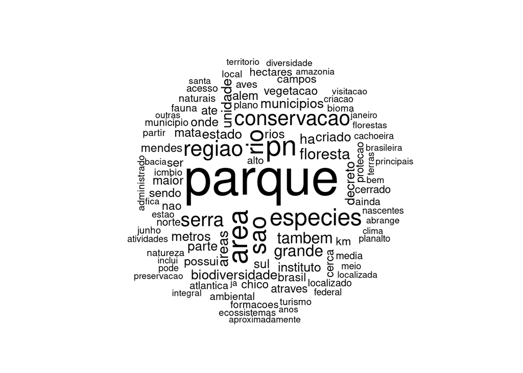

```r
wordcloud(
  words = frequencia_palavras$word,
  freq = frequencia_palavras$n,
  max.words = 100,
  random.order = FALSE
)
```

Experimente alterar `max.words` para 30 ou 200 e observe como a nuvem de palavras muda.

## Onde aprender um pouco mais?

- **Expressões regulares e *stringr* (em português)**: seção do livro *Ciência de Dados em R* do curso-r: https://livro.curso-r.com/7-4-o-pacote-stringr.html
- **Strings (em inglês)**: capítulo do *R for Data Science*: https://r4ds.had.co.nz/strings.html
- **Livro do *tidytext***: *Text Mining with R*: http://tidytextmining.com/
- **Capítulos sugeridos (após este tutorial)**:
  - Cap. 2 — Análise de Sentimento (inglês): http://tidytextmining.com/sentiment.html
  - Cap. 3 — Frequência de Palavras / TF-IDF: http://tidytextmining.com/tfidf.html
  - Cap. 4 — N-gramas e correlação: http://tidytextmining.com/ngrams.html
  - Cap. 6 — Topic Modeling: http://tidytextmining.com/topicmodeling.html